# Praca domowa 2

Michał Gwóźdź

## Dane

Dane wykorzystane w Pracy domowej 2 opisują wycenę nieruchmości. Każda obserwacja jest pewną nieruchmością, która posiada informacje takie jak powierzchnia, liczba pokoi, liczba łazienek i wiele więcj. Opis wszystkich kolumn w pliku `README.md`.

## Zadanie 1

Jak wygląda rozkład ceny nieruchomości w poszczególnych kodach pocztowych na przestrzeni lat? Rozważamy kody pocztowe, które mają więcej niż 280 posiadłości.

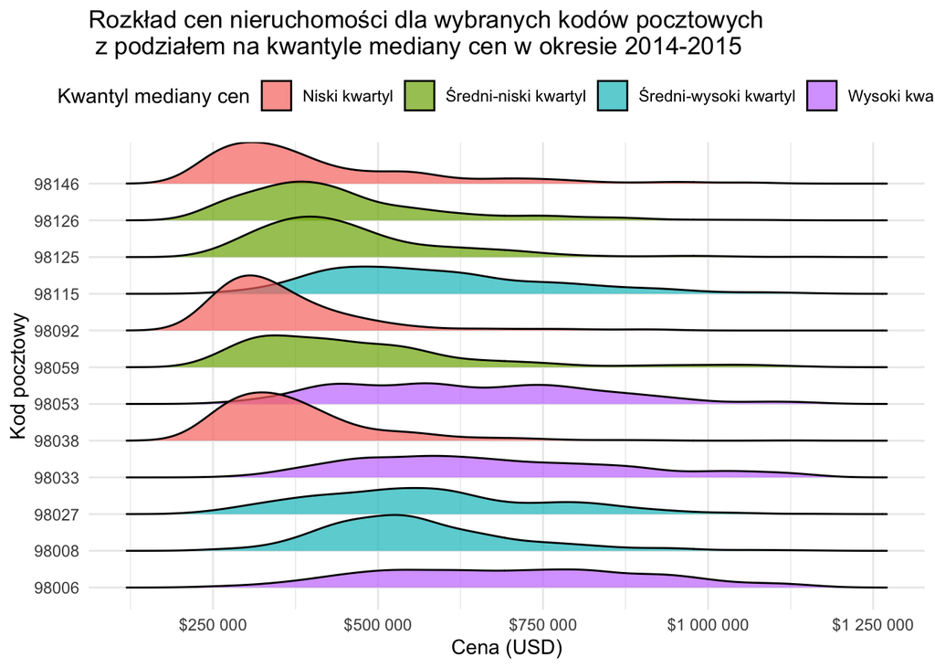

```r
# Filtrowanie kodów pocztowych, które mają więcej niż 280 nieruchomości
df_filtered <- df %>%
  group_by(zipcode) %>%
  filter(n() > 280)

# Obliczenie mediany ceny dla każdego kodu pocztowego
zipcode_medians <- df_filtered %>%
  group_by(zipcode) %>%
  summarise(median_price = median(price, na.rm = TRUE))

# Podział median cen na kwartyle i przypisanie etykiet
zipcode_medians <- zipcode_medians %>%
  mutate(
    quantile_group = ntile(median_price, 4),
    group = case_when(
      quantile_group == 1 ~ "Niski kwartyl",
      quantile_group == 2 ~ "Średni-niski kwartyl",
      quantile_group == 3 ~ "Średni-wysoki kwartyl",
      quantile_group == 4 ~ "Wysoki kwartyl"
    )
  )

# Losowy wybór 3 kodów pocztowych z każdego kwartyla
set.seed(123)
selected_zipcodes <- zipcode_medians %>%
  group_by(group) %>%
  sample_n(3) %>%
  pull(zipcode)

# Filtrowanie danych dla wybranych kodów pocztowych i dodanie grupy kwartyla
df_selected <- df_filtered %>%
  filter(zipcode %in% selected_zipcodes) %>%
  left_join(zipcode_medians %>% select(zipcode, group), by = "zipcode")

# Usunięcie outlierów poprzez ograniczenie do 5 i 95 percentyla
price_limits <- quantile(df_selected$price, probs = c(0.05, 0.95), na.rm = TRUE)
df_selected <- df_selected %>%
  filter(price >= price_limits[1], price <= price_limits[2])

# Tworzenie wykresu grzbietowego z podziałem na kwantyle i bez outlierów
ggplot(df_selected, aes(x = price, y = factor(zipcode), fill = group)) +
  geom_density_ridges(alpha = 0.7, scale = 1.5) +
  scale_x_continuous(labels = label_number(prefix = "$")) +
  labs(title = "Rozkład cen nieruchomości dla wybranych kodów pocztowych \n z podziałem na kwantyle mediany cen w okresie 2014-2015",
       x = "Cena (USD)",
       y = "Kod pocztowy") +
  theme_minimal() +
  theme(legend.position = "top") +
  guides(fill = guide_legend(title = "Kwantyl mediany cen"))
```

**Komentarz:**

Wykres ukazuje wyraźne różnice w rozkładzie cen nieruchomości pomiędzy kodami pocztowymi w zależności od kwartyla cenowego. Obszary należące do wyższych kwartali mediany cen (oznaczone jako „Średni-wysoki” i „Wysoki kwartyl”) mają rozkłady przesunięte ku wyższym wartościom cen, co wskazuje na wyższą wartość nieruchomości w tych lokalizacjach. Wysokie ceny w tych kodach pocztowych są również bardziej zróżnicowane, co świadczy o większym zakresie cen w bardziej pożądanych rejonach. W obszarach należących do niższych kwartali ceny są bardziej jednorodne i skoncentrowane w niższych zakresach, co sugeruje, że tańsze lokalizacje charakteryzują się mniejszym zróżnicowaniem w wartościach nieruchomości.

## Zadanie 2

Czy jest różnica w rozkładzie ceny nierchomości od powierzchni mieszkalnej uwzględniając podział na nieruchomości z piwnicą i bez?

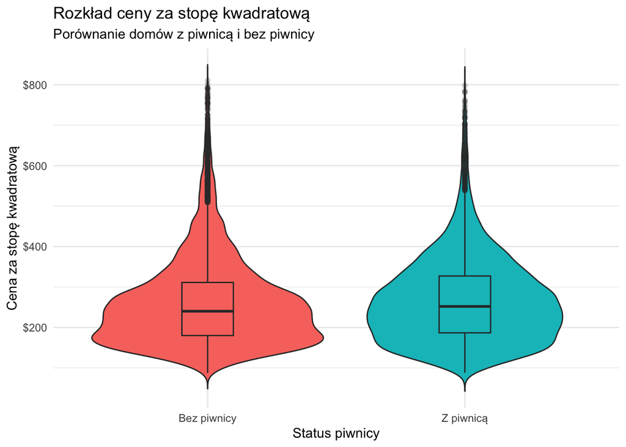

```r
# Przygotowanie danych
df_basement <- df %>%
  mutate(has_basement = ifelse(sqft_basement > 0, "Z piwnicą", "Bez piwnicy"),
         price_per_sqft = df$price / df$sqft_living)

# Violin plot pokazujący rozkład cen
ggplot(df_basement, aes(x = has_basement, y = price_per_sqft, fill = has_basement)) +
  geom_violin(trim = FALSE) +
  geom_boxplot(width = 0.2, alpha = 0.2) +
  scale_y_continuous(labels = scales::label_number(prefix = "$")) +
  labs(x = "Status piwnicy",
       y = "Cena za stopę kwadratową",
       title = "Rozkład ceny za stopę kwadratową",
       subtitle = "Porównanie domów z piwnicą i bez piwnicy") +
  theme_minimal() +
  guides(fill = "none")
```

**Komentarz:**

## Zadanie 3

Jaka jest zależność pomiędzy jakością wykończenia nieruchomości a liczbą pięter?

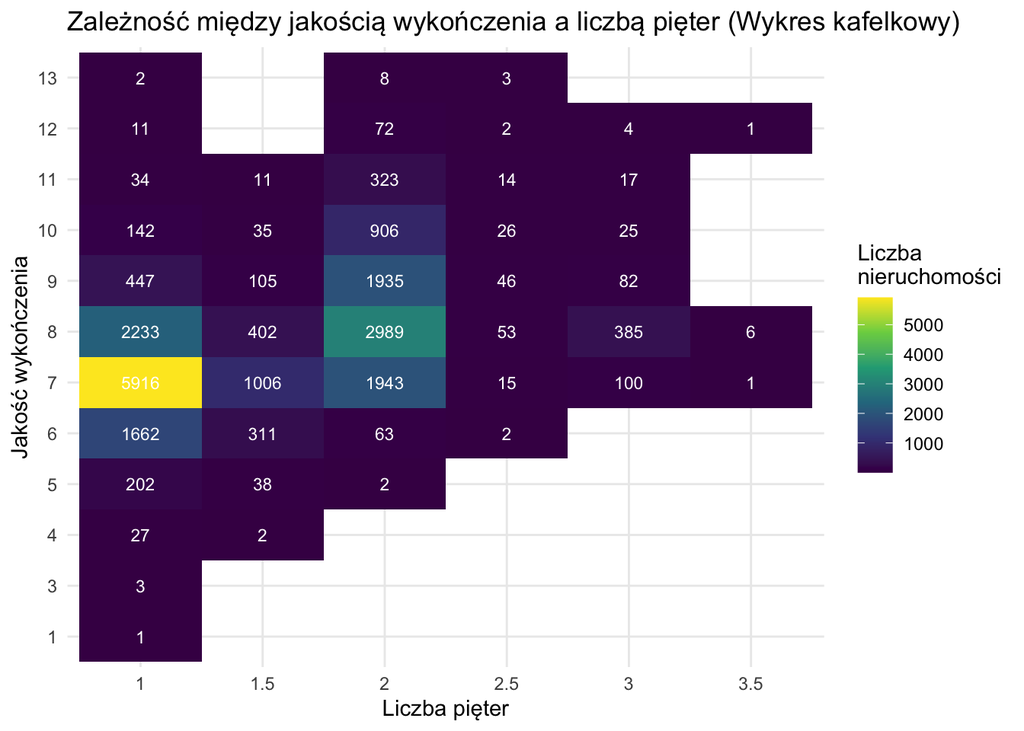

```r
# Przygotowanie danych
df_grade_floor_counts <- df %>%
  group_by(grade, floors) %>%
  summarise(count = n(), .groups = 'drop')

# Wykres kafelkowy
ggplot(df_grade_floor_counts, aes(x = as.factor(floors), y = as.factor(grade))) +
  geom_tile(aes(fill = count)) +
  scale_fill_viridis_c() +
  geom_text(aes(label = count), color = "white", size = 3) +
  labs(x = "Liczba pięter",
       y = "Jakość wykończenia",
       fill = "Liczba\nnieruchomości",
       title = "Zależność między jakością wykończenia a liczbą pięter (Wykres kafelkowy)") +
  theme_minimal()
```

**Komentarz:**

Na wykresie kafelkowym przedstawiono zależność między jakością wykończenia nieruchomości a liczbą pięter. Wartości w poszczególnych kafelkach oznaczają liczbę nieruchomości spełniających dane kryteria, a skala kolorystyczna wskazuje, że im jaśniejszy kolor, tym większa liczba nieruchomości. Najwięcej nieruchomości (5916) znajduje się na jednym piętrze i ma jakość wykończenia na poziomie 7, co jest zaznaczone na żółto. Wysoka jakość wykończenia (powyżej 8) jest częściej spotykana w nieruchomościach wielopiętrowych, natomiast niższe poziomy jakości są bardziej powszechne w budynkach jednopiętrowych.

Warto również zauważyć, że wśród domów o niższej jakości wykończenia (na poziomie 5 i niższym) praktycznie nie występują budynki o więcej niż jednym piętrze. Z kolei budynki o najwyższej jakości wykończenia są stosunkowo rzadkie. Widać zatem, że wzrost liczby pięter często wiąże się z wyższą jakością wykończenia – nieruchomości na wyższych piętrach (2-3 piętra) mają przeważnie wyższą jakość wykończenia, przy czym najwyższa liczba nieruchomości wielopiętrowych przypada na poziom jakości 7 i 8.

## Zadanie 4

Jaka jest zależność między powierzchnią mieszkalną nieruchomości a powierzchnią gruntu w podziale na liczbę sypialni?

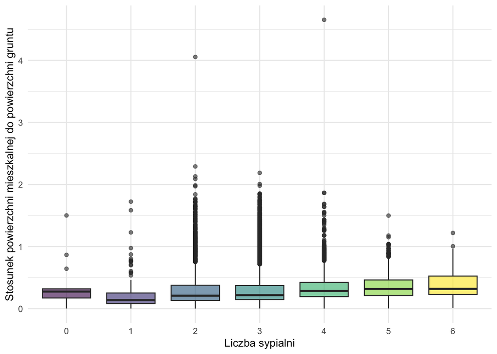

```r
#Wykres
ggplot(df %>% filter(bedrooms <= 6), aes(x = factor(bedrooms), y = sqft_living / sqft_lot)) +
  geom_boxplot(aes(fill = factor(bedrooms)), alpha = 0.6) +
  scale_fill_viridis_d() +
  labs(x = "Liczba sypialni", y = "Stosunek powierzchni mieszkalnej do powierzchni gruntu") +
  theme_minimal() +
  theme(legend.position = "none")
```

**Komentarz:**

Wykres przedstawia stosunek powierzchni mieszkalnej do powierzchni gruntu w zależności od liczby sypialni w nieruchomościach. Można zaobserwować lekką tendencję wzrostową mediany tego stosunku wraz ze wzrostem liczby sypialni – nieruchomości z większą liczbą sypialni mają nieco wyższy stosunek powierzchni mieszkalnej do gruntu. Warto jednak zauważyć, że stosunek ten jest wyraźnie mniejszy dla budynków z jedną sypialnią, co może sugerować, że tego typu nieruchomości mają zazwyczaj proporcjonalnie większą powierzchnię działki w stosunku do powierzchni mieszkalnej.

Na wykresie widoczne są również wartości odstające, szczególnie dla nieruchomości z 2, 3 i 4 sypialniami. Wartości te wskazują na istnienie wyjątkowych budynków z dużą powierzchnią mieszkalną w stosunku do gruntu w tych grupach. Podsumowując, choć istnieje lekka tendencja wzrostowa, stosunek powierzchni mieszkalnej do powierzchni gruntu jest stosunkowo stabilny w zależności od liczby sypialni.

## Zadanie 5

Rozważmy tylko nieruchomości, które miały remont. W której dekadzie było najwięcej przeprowadzonych remontów? Czy w poszczególnych dekadach jest porównywalny procent nieruchmości dla każdej wartości miary jakości i wykończenia nieruchomości?

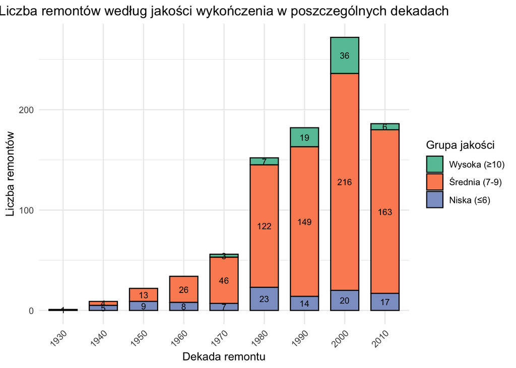

```r
# Przygotowanie danych tylko dla nieruchomości, które miały remont
df_renovated <- df %>%
  filter(yr_renovated > 0) %>%
  mutate(
    renovation_decade = floor(yr_renovated / 10) * 10,
    grade_group = case_when(
      grade <= 6 ~ "Niska (≤6)",
      grade <= 9 ~ "Średnia (7-9)",
      TRUE ~ "Wysoka (≥10)"
    ),
    grade_group = factor(grade_group, levels = c("Wysoka (≥10)", "Średnia (7-9)", "Niska (≤6)")) # Ustawienie kolejności
  )

# Obliczenie liczebności dla etykiet
counts_data <- df_renovated %>%
  group_by(renovation_decade, grade_group) %>%
  summarise(count = n(), .groups = 'drop')

# Wykres
ggplot(df_renovated, aes(x = as.factor(renovation_decade), fill = grade_group)) +
  geom_bar(width = 0.7, color = "black") +
  geom_text(
    data = counts_data,
    aes(y = count, label = count),
    position = position_stack(vjust = 0.5),
    size = 3
  ) +
  scale_fill_brewer(palette = "Set2") +
  labs(
    title = "Liczba remontów według jakości wykończenia w poszczególnych dekadach",
    x = "Dekada remontu",
    y = "Liczba remontów",
    fill = "Grupa jakości"
  ) +
  theme_minimal() +
  theme(
    plot.title = element_text(hjust = 0.5),
    axis.text.x = element_text(angle = 45, hjust = 1)
  )
```

## Zadanie 6

Jak prezentuje się wartość minimalna, średnia i maksymalna ceny nieruchmości w podziele na rok budowy nieruchomości.

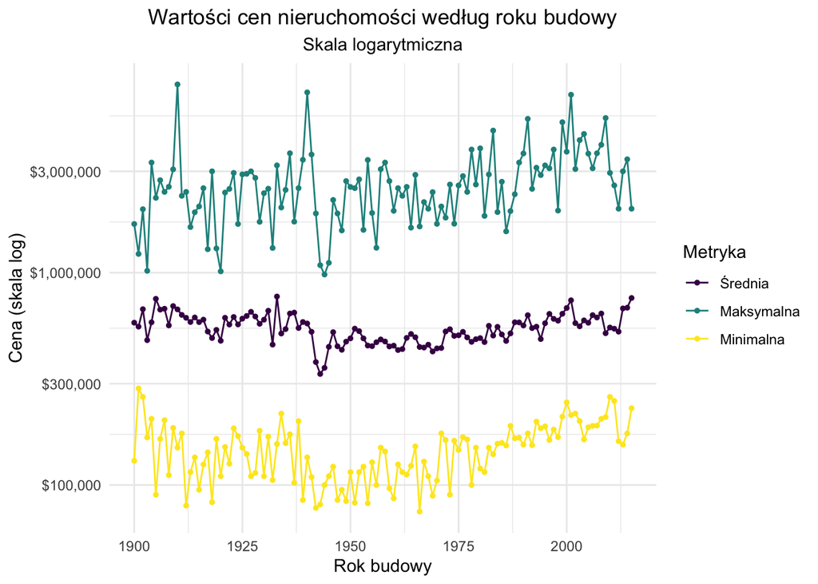

```r
# Przygotowanie danych dla cen maskymalnych, średnich i minimalnych
df_price_summary <- df %>%
  group_by(yr_built) %>%
  summarise(
    min_price = min(price),
    avg_price = mean(price),
    max_price = max(price)
  ) %>%
  pivot_longer(
    cols = c(min_price, avg_price, max_price),
    names_to = "metric",
    values_to = "price"
  )

# Wykres
ggplot(df_price_summary, aes(x = yr_built, y = price, color = metric)) +
  geom_line() +
  geom_point(size = 1) +
  scale_y_log10(labels = scales::dollar_format()) +
  theme_minimal() +
  labs(title = "Wartości cen nieruchomości według roku budowy",
       subtitle = "Skala logarytmiczna",
       x = "Rok budowy",
       y = "Cena (skala log)",
       color = "Metryka") +
  theme(plot.title = element_text(hjust = 0.5),
        plot.subtitle = element_text(hjust = 0.5)) +
  scale_color_viridis_d(labels = c("Średnia", "Maksymalna", "Minimalna"))
```

**Komentarz:** Wykres przedstawia wartości cen nieruchomości w zależności od roku budowy, uwzględniając trzy metryki: maksymalną, średnią i minimalną cenę, na skali logarytmicznej.

- Maksymalna cena wykazuje znaczną zmienność w czasie, co przejawia się jako wyraźne „piki” w wybranych latach. Najwyższe wartości maksymalne występują zarówno dla nieruchomości wybudowanych przed II wojną światową, jak i tych zbudowanych po 2000 roku, co może sugerować, że niektóre starsze i współczesne budynki są wyjątkowo wartościowe.
- Średnia cena jest bardziej stabilna niż maksymalna, ale wykazuje pewne wzorce. Nieruchomości zbudowane przed 1930 rokiem charakteryzują się wyższymi średnimi cenami, natomiast w latach 40. widać spadek. Od tego okresu średnia cena wykazuje trend wzrostowy, z lekkim spadkiem w budynkach z początku XXI wieku.
- Minimalna cena również zmienia się w zależności od roku budowy, z wyraźnymi „pikami” na początku XX i XXI wieku, podczas gdy najniższe wartości osiągają budynki wybudowane około 1950 roku.

Podsumowując, ceny nieruchomości różnią się w zależności od roku budowy, a wszystkie trzy metryki wskazują na większe wartości dla nieruchomości starszych (przed 1930) i współczesnych (po 2000).